# Australian Real Income by Education and Sex over Time

The latest version of this exploratory analysis is available at http://bit.ly/13rq35y. R source code for generating these plots is shown below, but note that confidentialized unit record files CURFs must be obtained from the ABS to completely reproduce the analysis. Full source code (excluding source data) is available on [GitHub](https://github.com/adrcooper/tasks).

The data used here are the ABS Surveys of Income and Housing (formerly, Income Distribution Survey), catalogue numbers 6543.0, 6541.0, 6503.0.

The data plotted below show only full-time, full-year workers whose main source of income are wages and salaries.

The surveys are conducted at three unit levels: households, income units, and individuals. For the purposes of this analysis, household and income unit data are discarded; the figures below are computed using person-level information. All data are weighted by the survey person weight.

Earned Income is taken to be total income from wages and salaries, including overtime, tips, bonuses and employer benefits. Real income is computed in 2013 dollars using the CPI deflator.

```r
library(ggplot2)
library(scales)
library(plyr)
suppressMessages(library(lmSupport))  # for partial R^2
library(isotone)  # for weighted median
library(xtable)
library(reshape2)
source("../lib/footnote.R")
source("../lib/plot_theme.R")
load("../data/curf/ftwswaw.rda")
# Standard footnote for figures
footnote <- function() {
    makeFootnote("Full-time wage/salary earners. 2013 AUD, CPI deflator. Source: ABS cat. 6543.0, 6541.0, 6503.0.")
}
```

## Comparison by Education Level

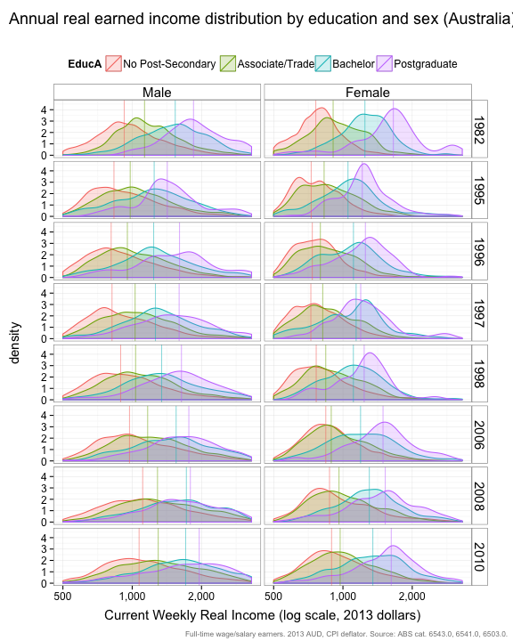

```r
ed_a <- which(!is.na(ftwswaw$EducA))  # rows where EducA is available
medians.EducA <- ddply(ftwswaw[ed_a, ], ~EducA + Sex + Year, summarise, mean = mean(CRInc),
    sd = sd(CRInc), median = weighted.median(CRInc, Weight))
p <- ggplot(ftwswaw[ed_a, ], aes(x = CRInc + 1, color = EducA, fill = EducA,
    weight = SexYearEducAWeight)) + geom_density(bw = "SJ", alpha = 0.2) + geom_vline(aes(xintercept = median,
    group = EducA, color = EducA), medians.EducA, linetype = "solid", alpha = 0.5) +
    scale_x_log10(labels = comma, limits = c(500, 3300), breaks = c(500, 1000,
        2000)) + facet_grid(Year ~ Sex) + ggtitle("Annual real earned income distribution by education and sex (Australia)") +
    xlab("Current Weekly Real Income (log scale, 2013 dollars)")
# NB: we suppress warnings since trimming the edges of the distribution
# means the area under the curves are no longer precisely equal to 1.
suppressWarnings(print(p))
footnote()
```

Earnings from wages and salaries, including tips and bonuses, in the week of the survey. Only respondents who reported working full-time and whose principal source of income are wages and salaries, are shown. Vertical lines represent the median income for each education level, within each sex/year cell. Real earnings are computed from nominal figures using the (untrimmed) CPI, centered at the midpoint of the reported fiscal year. Distributions are computed using Gaussian kernel densities with Sheather & Jones (1991) bandwidth, and the survey weight per person is re-scaled so that the area under each education/sex/year curve is 1. The (logarithmic) real earnings axis is truncated at $20k and $200k, in 2013 dollars.

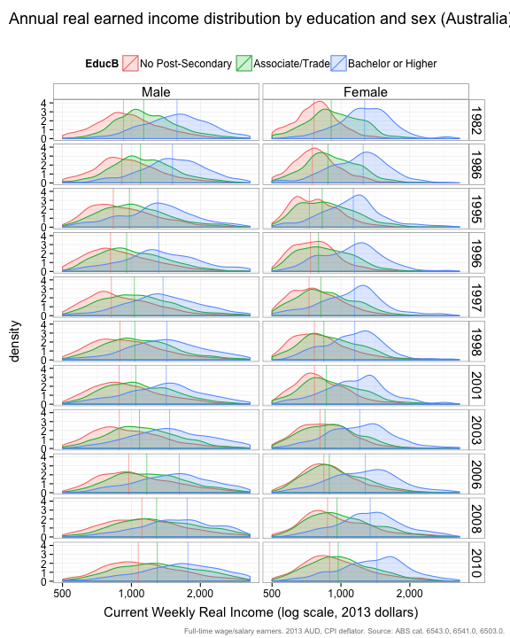

```r
medians.EducB <- ddply(ftwswaw, ~EducB + Sex + Year, summarise, mean = mean(CRInc),
    sd = sd(CRInc), median = weighted.median(CRInc, Weight))
p <- ggplot(ftwswaw, aes(x = CRInc + 1, color = EducB, fill = EducB, weight = SexYearEducBWeight)) +
    geom_density(bw = "SJ", alpha = 0.2) + geom_vline(aes(xintercept = median,
    group = EducB, color = EducB), medians.EducB, linetype = "solid", alpha = 0.5) +
    scale_x_log10(labels = comma, limits = c(500, 3300), breaks = c(500, 1000,
        2000)) + facet_grid(Year ~ Sex) + ggtitle("Annual real earned income distribution by education and sex (Australia)") +
    xlab("Current Weekly Real Income (log scale, 2013 dollars)")
# NB: we suppress warnings since trimming the edges of the distribution
# means the area under the curves are no longer precisely equal to 1.
suppressWarnings(print(p))
footnote()
```

Earnings from wages and salaries, including tips and bonuses, in the week of the survey. Only respondents who reported working full-time, and whose principal source of income are wages and salaries, are shown. Vertical lines represent the median income for each education level, within each sex/year cell. Real earnings are computed from nominal figures using the (untrimmed) CPI, centered at the midpoint of the reported fiscal year. Distributions are computed using Gaussian kernel densities with Sheather & Jones (1991) bandwidth, and the survey weight per person is re-scaled so that the area under each education/sex/year curve is 1. The (logarithmic) real earnings axis is truncated at $20k and $200k, in 2013 dollars.

A number of regularities are evident in the data above:

1. Education is less important as a predictor of real income earned (overlap of distributions is increasing),
2. For all education levels, income distribution is widening considerably (the tails are fatter).
3. The earnings differential between men and women appears is persistent.

Let's explore each of these trends one by one.

## 1. Education level declining as a predictor of income earned.

Let's look at the predictive power of education and sex on real income earned, as partial \( R^2 \), computed on education, each year.

```r
prsqsB <- data.frame(row.names = unique(ftwswaw$Year))
prsqsB$Sex <- NA
prsqsB$EducB <- NA
for (yr in levels(ftwswaw$Year)) {
    subs <- subset(ftwswaw, Year == yr)
    fit <- lm(CRInc ~ Sex + EducB, data = subs)
    ss <- lm.sumSquares(fit)
    prsqsB[yr, ] <- ss[c("EducB", "Sex"), "dR-sqr"]
}
prsqsB$Year <- as.numeric(rownames(prsqsB))
prsqsB_long <- melt(prsqsB, id.vars = "Year", value.name = "PRsq")
```

```r
print(xtable(prsqsB), type = "html")
```

|  | Sex | EducB | Year |
| --- | --- | --- | --- |
| 1982 | 0.16 | 0.07 | 1982.00 |
| 1986 | 0.14 | 0.05 | 1986.00 |
| 1995 | 0.07 | 0.02 | 1995.00 |
| 1996 | 0.11 | 0.04 | 1996.00 |
| 1997 | 0.12 | 0.04 | 1997.00 |
| 1998 | 0.08 | 0.03 | 1998.00 |
| 2001 | 0.10 | 0.03 | 2001.00 |
| 2003 | 0.12 | 0.04 | 2003.00 |
| 2006 | 0.11 | 0.05 | 2006.00 |
| 2008 | 0.07 | 0.04 | 2008.00 |
| 2010 | 0.10 | 0.04 | 2010.00 |

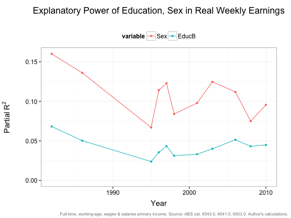

```r
p <- ggplot(prsqsB_long, aes(y = PRsq, x = Year, colour = variable)) + geom_line() +
    geom_point() + ggtitle("Explanatory Power of Education, Sex in Real Weekly Earnings") +
    ylab(expression("Partial R"^2)) + scale_y_continuous(limits = c(0, 0.16))
print(p)
makeFootnote("Full-time, working-age, wages & salaries primary income. Source: ABS cat. 6543.0, 6541.0, 6503.0. Author's calculations.")
```

## 2. Widening of the income distribution

The income distribution is widening, as in the United States and Europe. However, for all income groups, the median income is increasing, not decreasing, and the bottom 5% are doing comparatively well.

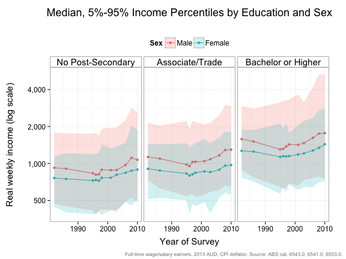

```r
ed_prop <- ddply(ftwswaw, ~EducB + Sex + Year, summarise, wmean = weighted.median(CRInc,
    SexYearWeight), w95 = weighted.fractile(CRInc, SexYearWeight, 0.95), w05 = weighted.fractile(CRInc,
    SexYearWeight, 0.05), wmedian = weighted.median(CRInc, Weight), wsum = sum(SexYearWeight)  # sum over education gives 1
)
ggplot(ed_prop, aes(x = as.numeric(as.character(Year)), y = wmedian, group = Sex)) +
    geom_line(aes(color = Sex)) + geom_point(aes(color = Sex)) + geom_ribbon(aes(ymin = w05,
    ymax = w95, fill = Sex), alpha = 0.2) + scale_x_continuous() + scale_y_log10(labels = comma,
    breaks = c(250, 500, 1000, 2000, 4000)) + facet_grid(. ~ EducB) + ggtitle("Median, 5%-95% Income Percentiles by Education and Sex") +
    xlab("Year of Survey") + ylab("Real weekly income (log scale)")
footnote()
```

### Relative supply of skilled labour

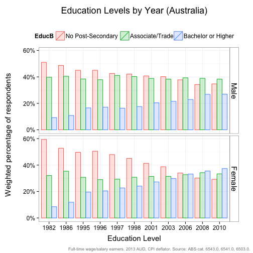

```r
ggplot(ed_prop, aes(x = Year, y = wsum, fill = EducB, colour = EducB)) + geom_bar(position = "dodge",
    stat = "identity", alpha = 0.2) + scale_y_continuous(labels = percent) +
    facet_grid(Sex ~ .) + ggtitle("Education Levels by Year (Australia)") +
    ylab("Weighted percentage of respondents") + xlab("Education Level")
footnote()
```

Proportions computed using person-level survey weights. Only respondents who reported working full-time, and whose principal source of income are wages and salaries, are shown.

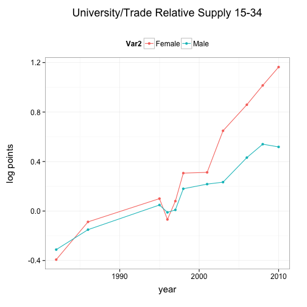

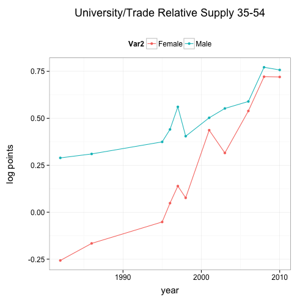

```r
hs_supp <- ddply(ftwswaw, ~EducB + Sex + Year + Age4, summarise, wsum = sum(Weight))
combo <- acast(hs_supp, Year ~ EducB ~ Sex ~ Age4, fun.aggregate = sum, value.var = "wsum")
combo[, 1, , ] <- log(combo[, 3, , ] + combo[, 2, , ]) - log(combo[, 1, , ])
for (a in 1:2) {
    age <- c("15-34", "35-54")
    slice <- melt(combo[, 1, , a], id = c("Sex", "Year"))
    p <- ggplot(slice, aes(x = Var1, y = value, group = Var2, color = Var2)) +
        geom_line() + geom_point() + ggtitle(paste("University/Trade Relative Supply",
        age[a])) + xlab("year") + ylab("log points")
    print(p)
}
```

### Cumulative change in Real Weekly Earnings

Note the faster growth of female wages relative to males. Further note the negligible real growth of male wages at the 10th percentile between 1982 and 2010. This reproduces Figure 7 in A&A.

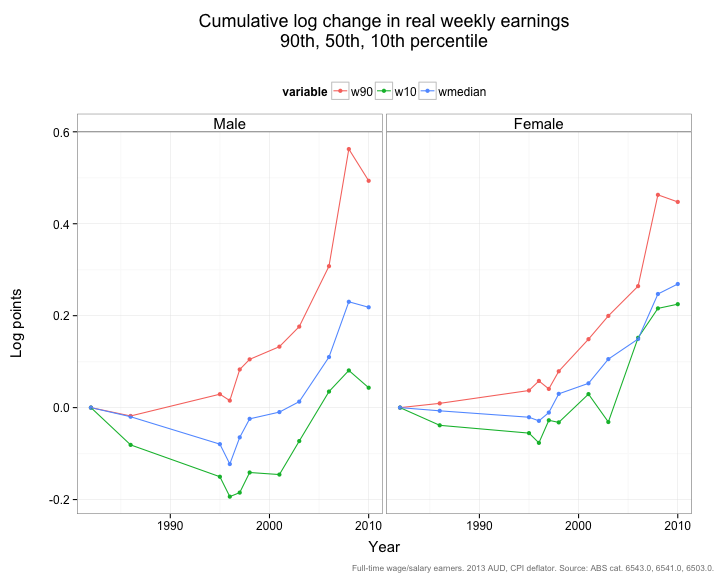

```r
log_chg <- ddply(ftwswaw, ~Sex + Year, summarise, w90 = weighted.fractile(log(CRInc),
    SexYearWeight, 0.95), w10 = weighted.fractile(log(CRInc), SexYearWeight,
    0.05), wmedian = weighted.median(log(CRInc), Weight))
for (sex in c("Male", "Female")) {
    subs <- with(log_chg, which(Sex == sex))
    for (c in c("w90", "w10", "wmedian")) {
        log_chg[subs, c] <- log_chg[subs, c] - log_chg[subs[1], c]
    }
}
ggplot(melt(log_chg), aes(x = as.numeric(as.character(Year)), y = value, group = variable,
    color = variable)) + geom_point() + geom_line() + facet_grid(. ~ Sex) +
    scale_x_continuous() + xlab("Year") + ylab("Log points") + ggtitle("Cumulative log change in real weekly earnings\n90th, 50th, 10th percentile")
footnote()
```

### Wage growth by fractile

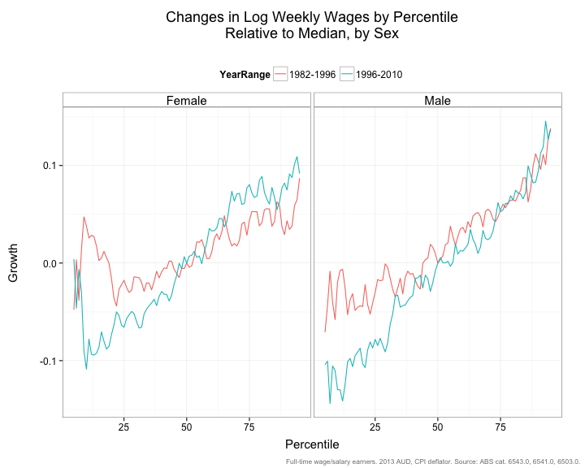

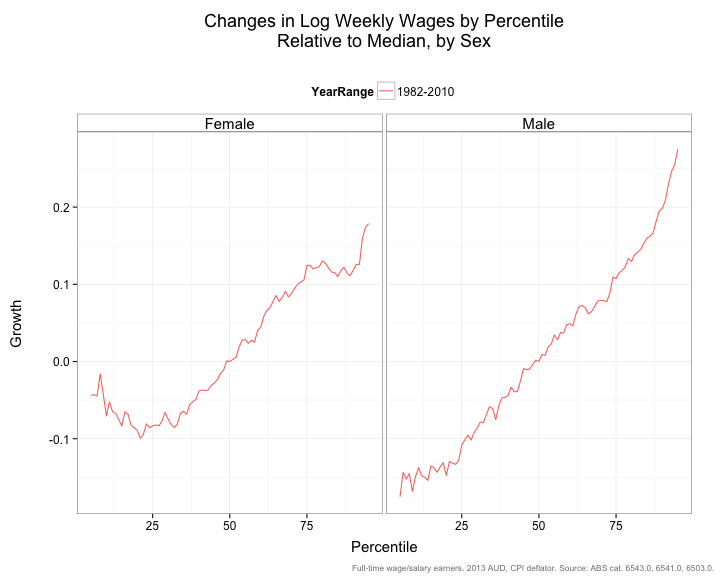

```r
wage_fractile_growth <- function(fracyears, sexes = c("Male", "Female")) {
    fractiles <- matrix(nrow = length(fracyears), ncol = 91)
    for (y in 1:length(fracyears)) {
        thisyear <- subset(ftwswaw, Year == fracyears[y] & Sex %in% sexes)
        frac <- function(p) with(thisyear, weighted.fractile(y = log(CRInc),
            w = Weight, p = p))
        fractiles[y, ] <- sapply(5:95/100, frac)
    }
    # compute log difference (ie percentage change)
    fracgrowth <- matrix(ncol = 91, nrow = length(fracyears) - 1, fractiles[2:length(fracyears),
        ] - fractiles[1:(length(fracyears) - 1), ])
    colnames(fracgrowth) <- 5:95
    # now make relative to median, so subtract the value in column '50' from
    # each row
    for (r in 1:(length(fracyears) - 1)) {
        fracgrowth[r, ] <- fracgrowth[r, ] - fracgrowth[r, 50 - 5 + 1]
    }
    # fracgrowth <- as.data.frame(fracgrowth)
    rownames(fracgrowth) <- paste(fracyears[1:(length(fracyears) - 1)], fracyears[2:length(fracyears)],
        sep = "-")
    fracgrowth_long <- melt(fracgrowth, id = "YearRange")
    colnames(fracgrowth_long) <- c("YearRange", "Percentile", "Growth")
    return(fracgrowth_long)
}

for (years in list(c(1982, 1996, 2010), c(1982, 2010))) {
    mgrowth <- wage_fractile_growth(years, "Male")
    mgrowth$Sex <- "Male"
    fgrowth <- wage_fractile_growth(years, "Female")
    fgrowth$Sex <- "Female"

    p <- ggplot(rbind(mgrowth, fgrowth), aes(x = Percentile, y = Growth, group = YearRange,
        colour = YearRange)) + geom_line() + facet_grid(. ~ Sex) + ggtitle("Changes in Log Weekly Wages by Percentile\nRelative to Median, by Sex")
    print(p)
    footnote()
}
```

## 3. The gender gap is persistent

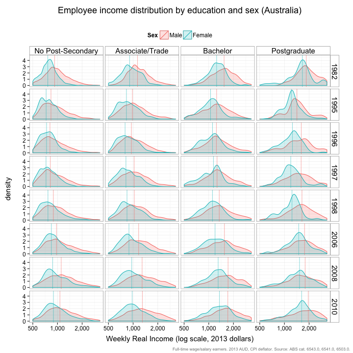

```r
p <- ggplot(ftwswaw[ed_a, ], aes(x = CRInc + 1, color = Sex, fill = Sex, weight = SexYearEducAWeight)) +
    geom_density(bw = "SJ", alpha = 0.2) + geom_vline(aes(xintercept = median,
    group = Sex, color = Sex), medians.EducA, linetype = "solid", alpha = 0.5) +
    scale_x_log10(labels = comma, limits = c(500, 3300), breaks = c(500, 1000,
        2000)) + facet_grid(Year ~ EducA) + ggtitle("Employee income distribution by education and sex (Australia)") +
    xlab("Weekly Real Income (log scale, 2013 dollars)")
# NB: we suppress warnings since trimming the edges of the distribution
# means the area under the curves are no longer precisely equal to 1.
suppressWarnings(print(p))
footnote()
```

## Job Polarization?

The ABS, bless their cotton socks, have used FOUR different occupational classification schemes throughout this data set. The most commonly used is the ASCO 2nd edition, used 1997-2006.

### ASCO I (1986-1995)

```r
asco <- with(ftwswaw, table(Asco, Year))
asco_p <- round(prop.table(asco, margin = 2) * 100, 1)
print(xtable(asco_p), type = "html")
```

|  | 1982 | 1986 | 1995 | 1996 | 1997 | 1998 | 2001 | 2003 | 2006 | 2008 | 2010 |
| --- | --- | --- | --- | --- | --- | --- | --- | --- | --- | --- | --- |
| 64 |  | 8.60 | 10.00 |  |  |  |  |  |  |  |  |
| 65 |  | 13.60 | 17.40 |  |  |  |  |  |  |  |  |
| 66 |  | 7.40 | 7.70 |  |  |  |  |  |  |  |  |
| 67 |  | 18.20 | 16.00 |  |  |  |  |  |  |  |  |
| 68 |  | 18.80 | 17.70 |  |  |  |  |  |  |  |  |
| 69 |  | 9.90 | 10.80 |  |  |  |  |  |  |  |  |
| 70 |  | 9.30 | 8.20 |  |  |  |  |  |  |  |  |
| 71 |  | 13.60 | 12.10 |  |  |  |  |  |  |  |  |
| 72 |  | 0.60 | 0.00 |  |  |  |  |  |  |  |  |

### ASCO II (1997-2006)

```r
asco <- with(ftwswaw, table(AscoII, Year))
asco_p <- round(prop.table(asco, margin = 2) * 100, 1)
print(xtable(asco_p), type = "html")
```

|  | 1982 | 1986 | 1995 | 1996 | 1997 | 1998 | 2001 | 2003 | 2006 | 2008 | 2010 |
| --- | --- | --- | --- | --- | --- | --- | --- | --- | --- | --- | --- |
| Advanced clerical and service workers |  |  |  |  | 4.00 | 3.80 | 3.80 | 3.40 | 2.80 |  |  |
| Associate professionals |  |  |  |  | 12.60 | 12.50 | 13.50 | 14.80 | 13.80 |  |  |
| Elementary clerical, sales and service workers |  |  |  |  | 6.30 | 6.20 | 6.00 | 5.90 | 5.30 |  |  |
| Inadequately described |  |  |  |  | 0.00 | 0.00 | 0.00 | 0.00 | 0.50 |  |  |
| Intermediate clerical, sales and service workers |  |  |  |  | 16.20 | 16.30 | 16.30 | 16.10 | 15.30 |  |  |
| Intermediate production and transport workers |  |  |  |  | 9.80 | 10.60 | 9.50 | 8.90 | 10.50 |  |  |
| Labourers and related workers |  |  |  |  | 7.80 | 7.00 | 7.40 | 6.60 | 6.90 |  |  |
| Managers and Administrators |  |  |  |  | 8.10 | 8.10 | 7.30 | 8.10 | 9.90 |  |  |
| Professionals |  |  |  |  | 19.90 | 20.90 | 22.10 | 22.80 | 22.00 |  |  |
| Tradespersons and related workers |  |  |  |  | 15.40 | 14.40 | 14.10 | 13.40 | 12.90 |  |  |

```
File:      explore/real_income_education_sex_year.Rmd
Run using: R version 3.0.0 (2013-04-03)
Run at:    2013-07-23 23:33:00.
```